# Merced County — English Learner Trends (2020–21 to 2025–26)

# 8. Immigration Policy Climate & Enrollment Decline

The year-over-year charts show enrollment fluctuations, but the *cause* of a decline matters as much as the fact of it. This section situates the enrollment data within the federal immigration policy timeline.

**Policy context:**

[output not shown]

The mechanism connecting federal enforcement to local school enrollment is called the **chilling effect**: when immigration enforcement becomes more visible or aggressive, families — including those with legal status — reduce participation in public institutions out of fear. Mixed-status households, where some members are citizens or legal residents and others are undocumented, face the highest exposure. Research following the 287(g) agreements and ICE workplace raids of the 2010s consistently documented drops in school attendance and enrollment in counties with high undocumented immigrant populations, even among U.S.-born children.

Merced County is structurally vulnerable to this effect. Agricultural labor — the economic backbone of Livingston, Dos Palos, and Los Banos — has historically employed a significant undocumented workforce. These are not anonymous statistics: they are families in the same school districts, attending the same schools that generate the EL counts in this dataset.

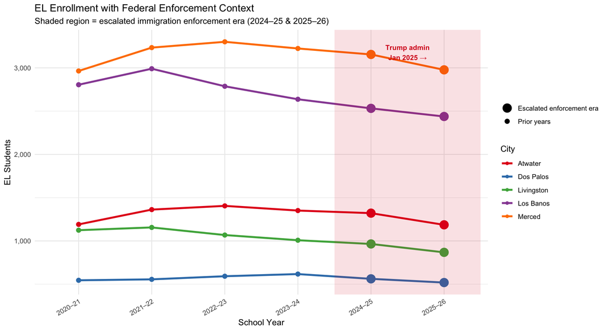

```r
# Highlight the 2024-25 year to isolate the current enforcement period
el_city_yr |>
  mutate(enforcement_era = if_else(school_year %in% c("2024–25", "2025–26"),
                                   "Escalated enforcement era",
                                   "Prior years")) |>
  ggplot(aes(x = school_year, y = total_el, group = city)) +
  geom_line(aes(color = city), linewidth = 1.2) +
  geom_point(aes(color = city, size = enforcement_era)) +
  scale_size_manual(values = c("Escalated enforcement era" = 5, "Prior years" = 2.5)) +
  scale_color_brewer(palette = "Set1") +
  scale_y_continuous(labels = comma) +
  annotate("rect",
           xmin = 4.5, xmax = 6.5,
           ymin = -Inf, ymax = Inf,
           alpha = 0.12, fill = "#d7191c") +
  annotate("text", x = 5.5, y = Inf, vjust = 2,
           label = "Trump admin\nJan 2025 →",
           size = 3.2, color = "#d7191c", fontface = "bold") +
  labs(title = "EL Enrollment with Federal Enforcement Context",
       subtitle = "Shaded region = escalated immigration enforcement era (2024–25 & 2025–26)",
       x = "School Year", y = "EL Students",
       color = "City", size = NULL) +
  theme_minimal() +
  theme(axis.text.x = element_text(angle = 30, hjust = 1))
```

**Interpretation:** A drop in EL enrollment during 2024–25, particularly in agricultural cities like Livingston and Dos Palos, is consistent with the documented chilling effect of increased enforcement. These communities have the highest structural exposure: high proportions of agricultural workers, mixed-status households, and limited institutional buffer from legal aid or advocacy organizations compared to urban centers like Fresno or Sacramento.